# Light partitioning modeling report

2023-02-24

#### Load dataset options for simultaneous records:

```r
# MR's original
tar_load(simul)
# Our attempt at recreating MR's data
tar_load(simultaneous_data)
# A stricter version
tar_load(simultaneous_data_strict)
```

### Overview of simultaneous records

#### Differences in number of rows:

The **original** simultaneous Light Partitioning dataset based on AquaSat downloads and MR’s scripts has 100,853 records. **Our attempt** at achieving a similar number of rows using the current version of the WQP harmonization workflow contains 55,675 records. A **stricter** version of our dataset contains 25,894 records.

Most decisions regarding harmonization choices and filtering for the two more current datasets can be found in `3_harmonize/src/clean_wqp_data.R`, `3_harmonize/src/harmonize_[param].R`, and similarly named functions with `_strict` appended for the version used on the stricter dataset.

The stricter of our two datasets contains a few more filters than the other datasets:

1. While cleaning the raw WQP data for later use, missing rows are removed. This likely has little to no effect on the dataset given that downstream steps should remove most or all of these
2. DOC: Michael Meyer’s “inclusive” tier of analytical methods is dropped from this version. This and other tiering match tables will be included as csv files
3. SDD: Matt Brousil’s “unlikely” grouping for sampling methods is dropped from this version. The same grouping is dropped from collection equipment as well
4. TSS: Katie Willi’s “ambiguous” tiers for analytical methods are dropped from this version

#### Differences between the the two larger datasets:

MR’s dataset (`simul`) and our attempt at recreating it (`simultaneous_data`) do not match in size.

While investigating the reason behind this, MRB found ~1.4 million site-date-parameter combinations in MR’s `wqp_lagos_unity.csv` download, after removing LAGOS, that we don’t have in our raw WQP download using the current workflow method. Of those 1.4 million combos we don’t have the parameter breakdown is: chla 34k, doc 33k sdd 92k, tss 1.2 million.

Within the 1.4 million missing combinations, 7.7k - 15.1k are sites we don’t have at all in our WQP download. This range is due to some uncertainty from us intentionally dropping one of the tss `CharacteristicName`s. We’re unfortunately limited in how much we can dig into the dataset differences further. It would take more time to understand how the original AquaSat’s WQP querying process differs from the USGS method we’ve based our pipeline on. The original dataset downloaded for MR’s version has also been processed to the point where many columns that would help with comparing versions have been dropped.

KW did a quick download of the four parameters from WQP using her own method and found that her number of records still differed from MR’s.

tldr: We tried to create a perfect, updated match to MR’s `simul` dataset but hit a wall.

#### Maps of current records

**MR’s original dataset**:

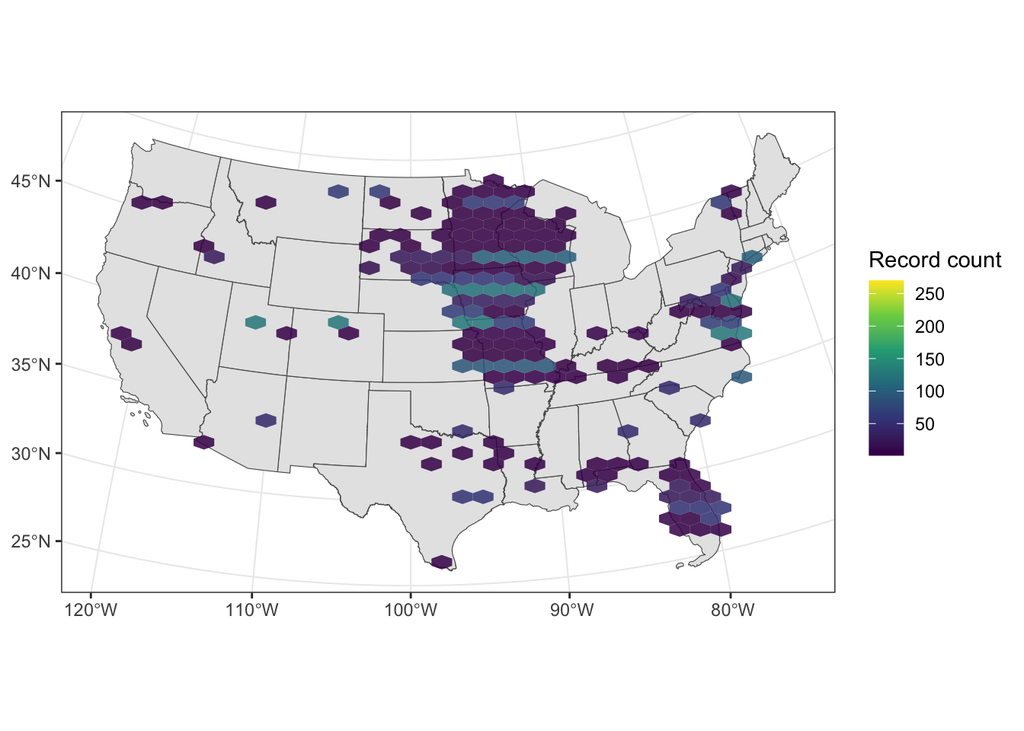

```r
tar_read(simul_vis_gg_mr)
```

**Our dataset**:

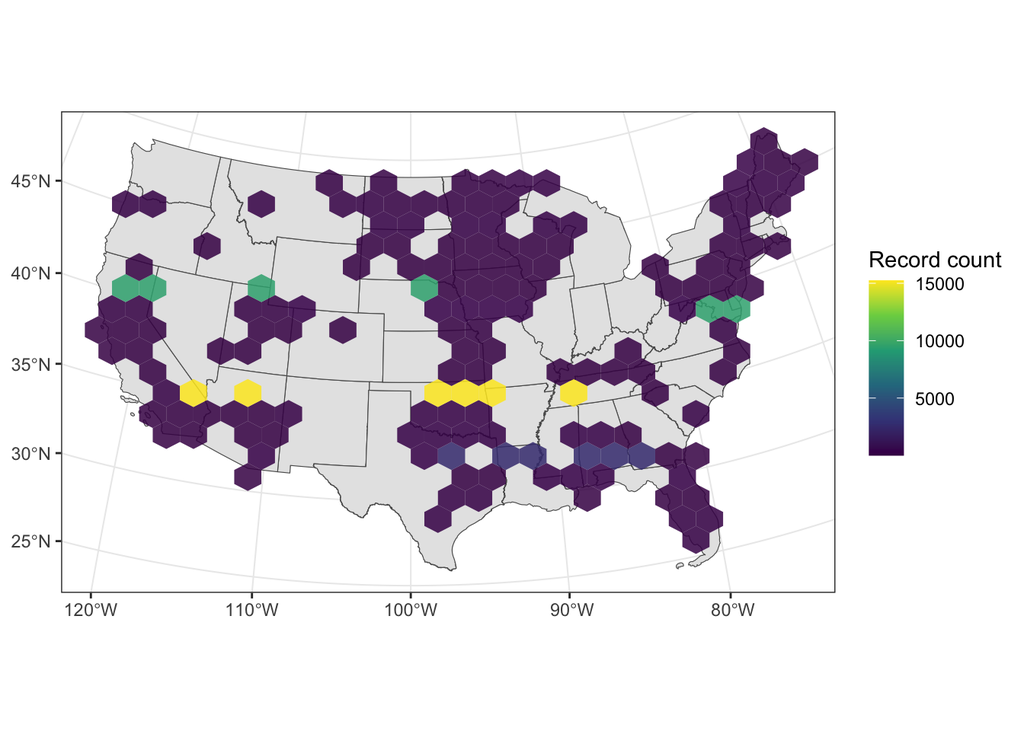

```r
tar_read(simul_vis_gg)
```

**Our strict dataset**:

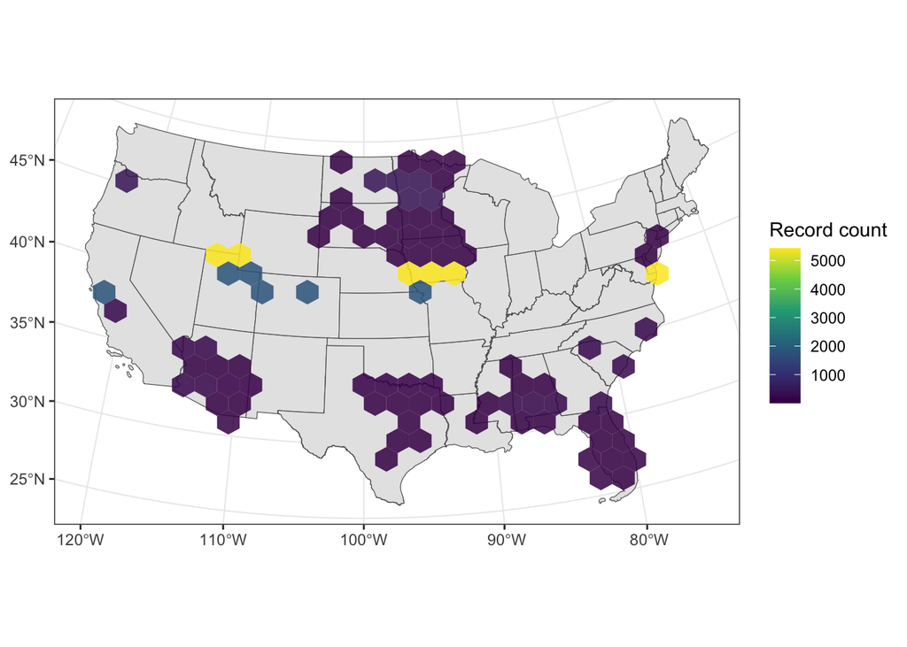

```r
tar_read(simul_vis_gg_strict)
```

### Comparisons against MR’s AquaSat 1 version:

#### Parameter distributions

**MR’s original dataset**:

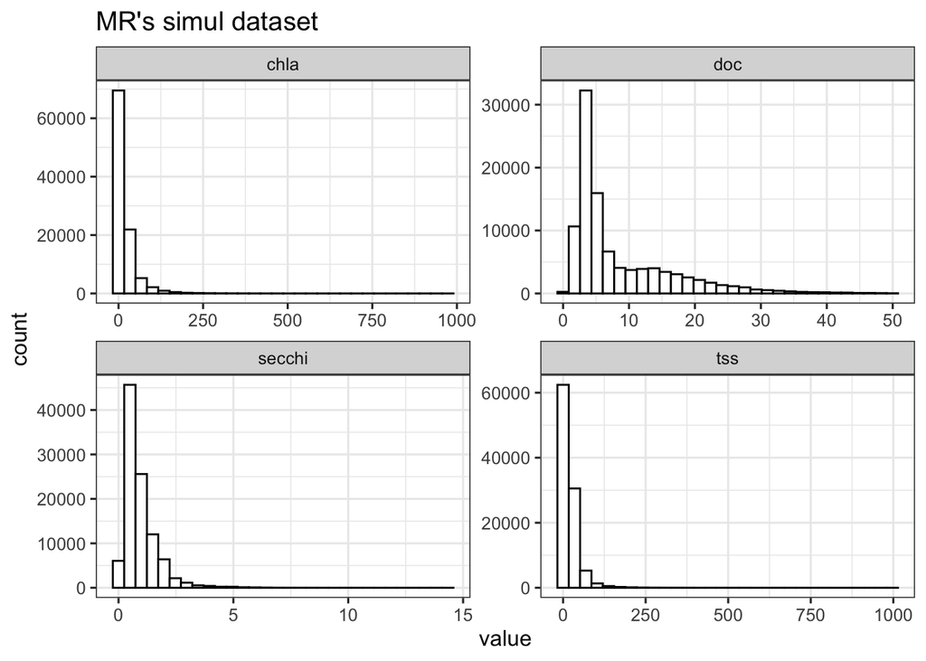

**Our dataset**:

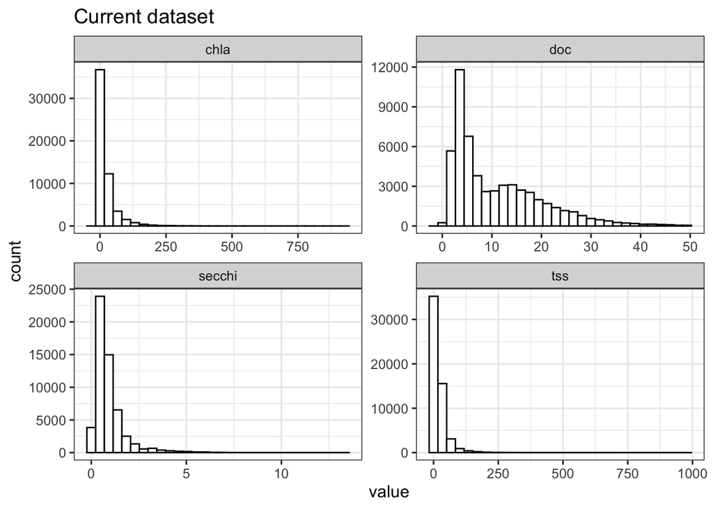

**Our strict dataset**:

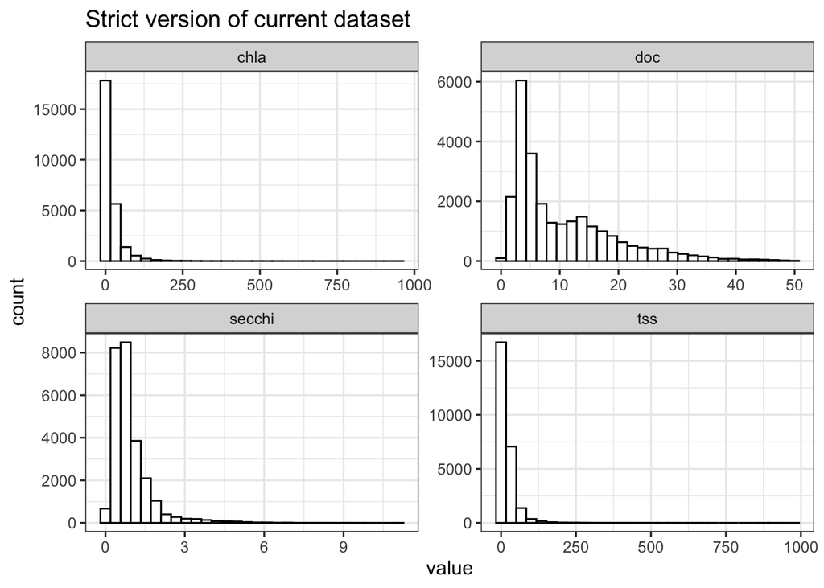

**Comparison table**:

| parameter | dataset | mean_val | sd_val |
| --- | --- | --- | --- |
| chla | Current dataset | 22.38 | 38.95 |
| chla | MR simul | 19.74 | 33.55 |
| chla | Strict dataset | 19.03 | 32.45 |
| doc | Current dataset | 11.02 | 9.04 |
| doc | MR simul | 8.59 | 7.85 |
| doc | Strict dataset | 10.50 | 8.86 |
| secchi | Current dataset | 0.92 | 0.86 |
| secchi | MR simul | 0.95 | 0.78 |
| secchi | Strict dataset | 0.94 | 0.80 |
| tss | Current dataset | 20.80 | 32.08 |
| tss | MR simul | 21.02 | 30.29 |
| tss | Strict dataset | 19.93 | 32.32 |

### Modeling

We’ll run the linear model with all three versions of the dataset. The code below is adapted from MR’s scripts.

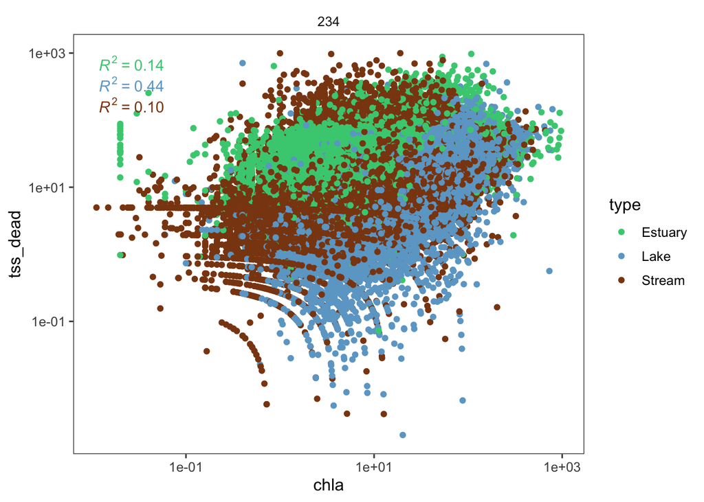

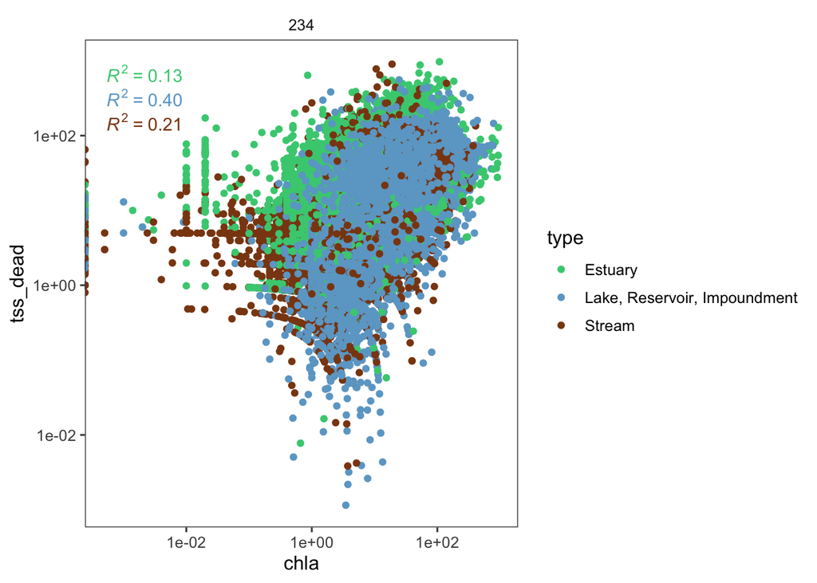

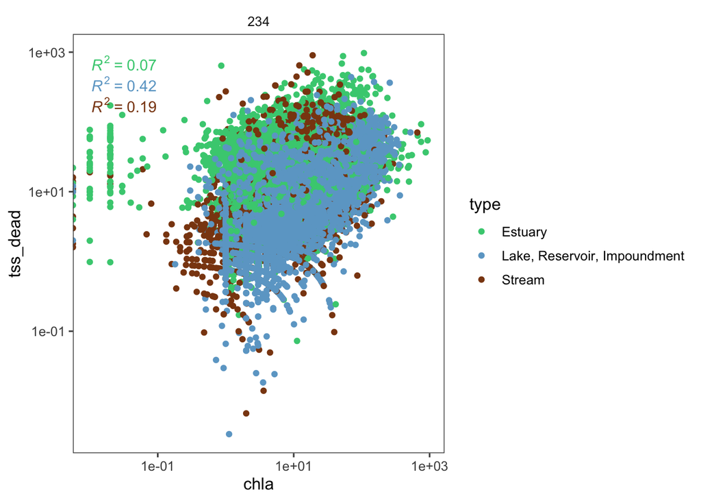

```r
range_val <- 234

# Multiply chla by 234
nap_test <- map(.x = list(simul = rename(simul, chla = chl_a),
                          simultaneous_data = simultaneous_data,
                          simultaneous_data_strict = simultaneous_data_strict),
                .f = ~ expand_grid(.x, chl_ratio = range_val) %>%
                  mutate(power = ifelse(chl_ratio == 234, 0.57, 1),
                         chla_biomass = exp(log(chl_ratio / 1000) + log(chla) * power),
                         tss_dead = tss - chla_biomass))
map(.x = nap_test,
    .f = ~ .x %>%
      #Remove negatives and very small numbers (ug/L of sediment is basically zero)
      filter(tss_dead > 0.001) %>%
      # sample_frac(0.1) %>%
      ggplot(., aes(chla,tss_dead,color = type)) +
      facet_wrap(~chl_ratio) +
      geom_point() +
      scale_x_log10() +
      scale_y_log10() +
      stat_poly_eq() +
      ggthemes::theme_few() +
      scale_color_manual(values = c('seagreen3','skyblue3','saddlebrown')))
```

```r
nap_est <- map(.x = nap_test,
               .f = ~ .x %>%
                 filter(tss_dead > 0.001) %>%
                 mutate(secchi = ifelse(secchi < 0.01, 0.01, secchi),
                        kd = (1 / secchi)))
```

```r
model <- map(.x = nap_est,
             .f = ~ lm(kd ~ tss_dead + doc + chla, data = .x))

nap_resid <- map2(.x = nap_est,
                  .y = model,
                  .f = ~ .x %>%
                    mutate(residuals = .y$residuals,
                           pred = .y$fitted.values))

model_metrics <- pmap_df(.l = list(nap_resid = nap_resid,
                                   name = names(nap_resid),
                                   model = model),
                         .f = function(nap_resid, name, model){
                           dataset <- name
                           rmse <- round(rmse(nap_resid$kd, nap_resid$pred), 2)
                           adj_rsq <- round(unlist(summary(model)["adj.r.squared"][1]), 2)

                           tibble(dataset = dataset,
                                  rmse = rmse,
                                  adj_rsq = adj_rsq)
                         })

model_metrics %>%
  left_join(x = .,
            y = tibble(
              dataset = c("simul", "simultaneous_data", "simultaneous_data_strict"),
              rows = c(nrow(simul), nrow(simultaneous_data), nrow(simultaneous_data_strict))),
            by = c("dataset")) %>%
  kable() %>%
  kable_paper()
```

| dataset | rmse | adj_rsq | rows |
| --- | --- | --- | --- |
| simul | 1.96 | 0.16 | 100853 |
| simultaneous_data | 1.85 | 0.23 | 55675 |
| simultaneous_data_strict | 1.34 | 0.37 | 25894 |